# Introduction to Bayesian Statistics with R

14 May 2024

## Diamond data

Dataset of the price of diamonds, which depends on the 4 C’s **De Veaux, 2015**

- Carats (weight, 1 carat = 0.2g)
- Colour (white to yellow, D:K)
- Clarity (whether marks/inclusions are present)
- Cut (how well shaped)

```r
# Read in the file, with character columns as factors
diamond_data <- read.csv("./data/diamonds.csv", as.is = FALSE)
head(diamond_data)
```

```
##   Price Carats Color Clarity       Cut
## 1  1000   0.30     E    VVS1 Excellent
## 2  1000   0.44     E     VS2 Excellent
## 3  1000   0.31     E    VVS1 Excellent
## 4  1000   0.66     K     SI1 Excellent
## 5  1000   0.47     H     VS2 Very Good
## 6  1000   0.40     G     VS1 Excellent
```

Question: how are diamonds distributed over the categorical variables?

- geom_bar

## Diamond categories

```r
# plot bar chart of Color
ggplot(diamond_data, aes(x = Color)) +
  geom_bar(col = "darkorange", alpha = 0.5)
```

```r
summary(diamond_data$Color)
```

```
##   D   E   F   G   H   I   J   K
## 277 504 431 396 394 316 253 119
```

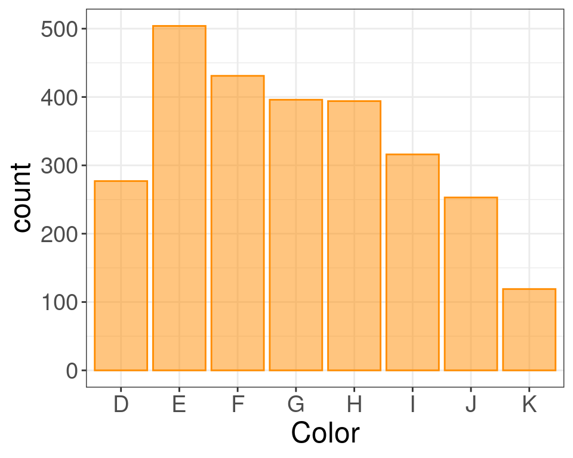

But the alphabetical order is only good for colour!

```r
diamond_data$Clarity <- factor(diamond_data$Clarity, levels=c("IF","VVS1","VVS2","VS1","VS2","SI1","SI2"))
diamond_data$Cut <- factor(diamond_data$Cut, levels = c("Ideal", "Excellent", "Very Good", "Good"))
```

Question: What about the continuous variables?

## Diamond continuous

```r
ggplot(diamond_data, aes(x = Price,
  y = ..density..)) + # histogram of Price
geom_histogram(col = "darkorange", alpha = 0.5)
```

```r
summary(diamond_data$Price)
```

[output not shown]

Question: Shall we log-transform?

[figure not shown]

- *Price* is to the nearest dollar
- *Carats* measured to nearest 0.01

```r
diamond_data$log_Price <- log(diamond_data$Price + 1)
diamond_data$log_Carats <- log(diamond_data$Carats + 0.01)
```

## Price vs Colour

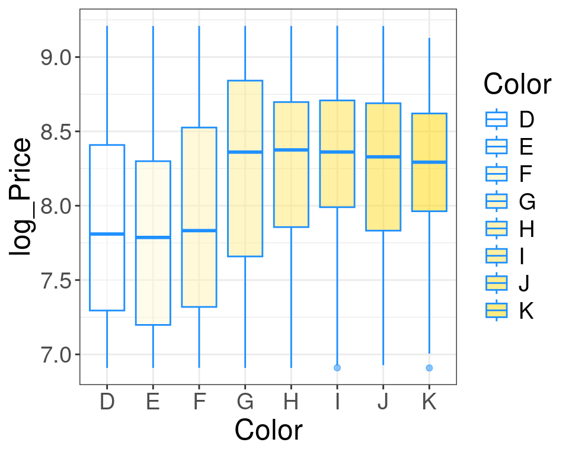

```r
# colour the price data by the colour
ggplot(diamond_data, aes(x = Color,
       y = log_Price, fill = Color)) +
# add box plots with transparency
  geom_boxplot(colour = "dodgerblue",
               alpha = 0.5) +
# change colours
  scale_fill_manual(values = colorRampPalette(
    c("white", "Gold"))(8)) +
# and font size and theme
  theme_bw() +
  theme(text = element_text(size = 18))
```

Question: Do you notice anything odd?

Question: Why?

## Size vs Colour

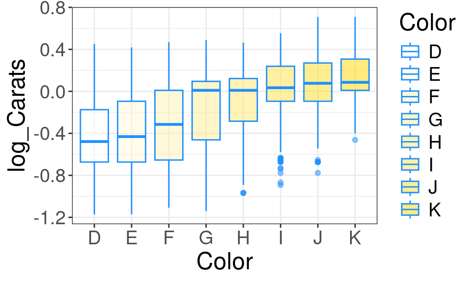

```r
# colour the size data by the colour
ggplot(diamond_data, aes(x = Color,
       y = log_Carats, fill = Color)) +
# add box plots with transparency
  geom_boxplot(colour = "dodgerblue",
               alpha = 0.5) +
# change colours
  scale_fill_manual(values = colorRampPalette(
    c("white", "Gold"))(8)) +
# and font size and theme
  theme_bw() +
  theme(text = element_text(size = 18))
```

Answer: They are also larger.

Question: Which model could we build to start to account for this?

Answer:

\[\mathrm{log\_Price} = \beta_0 + \beta_1\mathrm{log\_Carats} + \beta_2\mathrm{Color}+\varepsilon\]

## Multiple regression

base R

With the lm(…) function

```r
lm_diamond_fit <- lm(log_Price ~ log_Carats + Color, diamond_data)
summary(lm_diamond_fit)$coefficients
```

```
##                Estimate Std. Error    t value      Pr(>|t|)
## (Intercept)  8.66400438 0.01497973 578.382006  0.000000e+00
## log_Carats   1.74452061 0.01306870 133.488448  0.000000e+00
## ColorE      -0.07508179 0.01712718  -4.383780  1.211285e-05
## ColorF      -0.12773430 0.01770132  -7.216089  6.933227e-13
## ColorG      -0.16818959 0.01834570  -9.167794  9.346905e-20
## ColorH      -0.29741524 0.01867019 -15.929953  1.168899e-54
## ColorI      -0.39879148 0.01987136 -20.068654  1.411883e-83
## ColorJ      -0.54260957 0.02101840 -25.815926 1.941359e-131
## ColorK      -0.65972524 0.02618470 -25.195065 6.773399e-126
```

- *log_Carats* row contains \(\beta_1\) which is the slope
- *Color* rows are the offset compared to the baseline D

Question: How much would the predicted log_Price change if we increase the log_Carat size by 0.4 and change the colour from D to J?

Answer: 0.4*1.7445-0.5426 = 0.1552.

## Predicted values

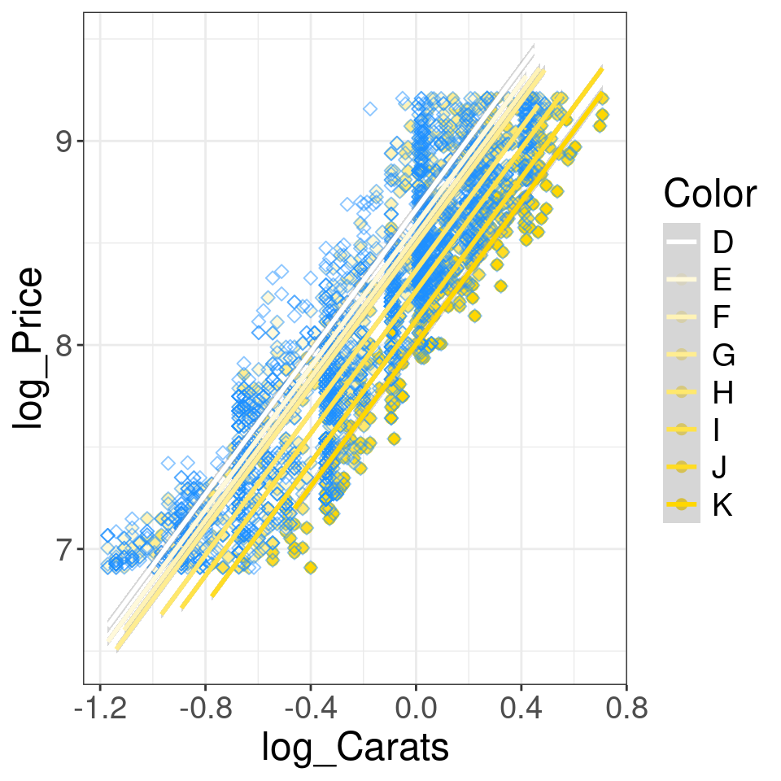

```r
# the slope
beta_1 <- summary(lm_diamond_fit)$
                  coefficients[2, 1]
# colour the price size data by the colour
ggplot(diamond_data, aes(x = log_Carats,
        y = log_Price, colour = Color)) +
# add points with outline
  geom_point(aes(colour = Color), size = 2) +
  geom_point(shape = 23, size = 2,
         colour = "dodgerblue", alpha = 0.5) +
# change colours
  scale_color_manual(values = colorRampPalette(
    c("white", "Gold"))(8)) +
# add the fit lines with fixed slope
    geom_smooth(method = lm,
          formula = y ~ 1 + offset(beta_1*x)) +
# and font size and theme
  theme_bw() +
  theme(text = element_text(size = 18))
```

Question: should the lines all have the same slope?

## Interactions

If \(x_1\) is continuous and \(x_2\) categorical with \((K+1)\) categories, in the regression

\[y = \beta_0 + \beta_1 x_1 + \beta_2 x_2 + \epsilon\]

The predicted values are

\[\widehat{y} = \left\{ \begin{array}{ccc}\beta_0 + \beta_1x_1 & & k=0 \\ \beta_0 + \beta_1x_1 + \beta_{2,k} && k>0 \end{array} \right.\]

- \(k\) is the category of \(x_2\), changes the intercept

To change the slope, we add the interaction term

\[y = \beta_0 + \beta_1 x_1 + \beta_2 x_2 + \beta_3x_1x_2+ \epsilon\]

Question: What are the predicted values?

Answer:

\[\widehat{y} = \left\{ \begin{array}{ccc}\beta_0 + \beta_1x_1 & & k=0 \\ \beta_0 + \beta_1x_1 + \beta_{2,k} + \beta_{3,k}x_1 && k>0 \end{array} \right.\]

## Interaction terms

base R

With the lm(…) function

```r
lm_diamond_fit2 <- lm(log_Price ~ log_Carats*Color, diamond_data) # includes linear terms too
summary(lm_diamond_fit2)$coefficients
```

```
##                      Estimate Std. Error     t value      Pr(>|t|)
## (Intercept)        8.62577313 0.02189756 393.9148400  0.000000e+00
## log_Carats         1.66020661 0.03778372  43.9397322 6.186315e-318
## ColorE            -0.08867188 0.02691755  -3.2942031  9.998794e-04
## ColorF            -0.09739489 0.02637480  -3.6927246  2.263035e-04
## ColorG            -0.12344324 0.02519454  -4.8996037  1.017603e-06
## ColorH            -0.25299284 0.02481962 -10.1932596  5.793530e-24
## ColorI            -0.36268061 0.02537885 -14.2906641  1.062021e-44
## ColorJ            -0.51705979 0.02630919 -19.6532035  1.971338e-80
## ColorK            -0.63145725 0.03160116 -19.9820925  6.612832e-83
## log_Carats:ColorE -0.03380434 0.04658013  -0.7257246  4.680712e-01
## log_Carats:ColorF  0.06072474 0.04786126   1.2687659  2.046350e-01
## log_Carats:ColorG  0.12550489 0.04933340   2.5440144  1.101447e-02
## log_Carats:ColorH  0.18490199 0.05429696   3.4053834  6.704605e-04
## log_Carats:ColorI  0.15856366 0.05778674   2.7439455  6.111086e-03
## log_Carats:ColorJ  0.29093493 0.06189074   4.7007831  2.723032e-06
## log_Carats:ColorK  0.16872252 0.08727229   1.9332885  5.330611e-02
```

- *log_Carats:Color* rows are change in slope compared to the baseline D

## Predicted values with interactions

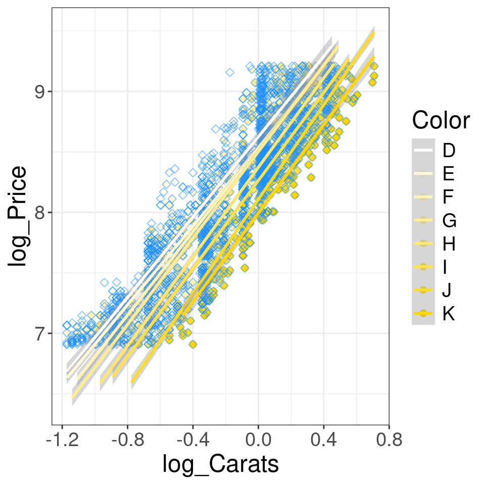

```r
# colour the price size data by the colour
ggplot(diamond_data, aes(x = log_Carats,
        y = log_Price, colour = Color)) +
# add points
  geom_point(aes(colour = Color), size = 2) +
  geom_point(shape = 23, size = 2,
         colour = "dodgerblue", alpha = 0.5) +
# change colours
  scale_color_manual(values = colorRampPalette(
    c("white", "Gold"))(8)) +
# add the fit lines without specifying slope
    geom_smooth(method = lm) +
# and font size and theme
  theme_bw() +
  theme(text = element_text(size = 18))
```

Question: How do the residuals look?

## Residuals and covariates

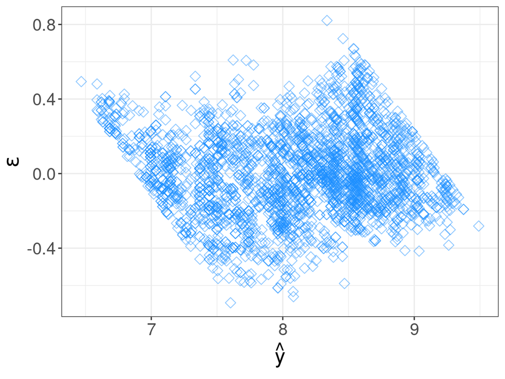

Question: What about the other covariates?

## Adding clarity to the model

base R

With the lm(…) function

```r
lm_diamond_fit3 <- lm(log_Price ~ log_Carats*(Color + Clarity), diamond_data)
summary(lm_diamond_fit3)$coefficients[1:15, ]
```

```
##                Estimate Std. Error    t value      Pr(>|t|)
## (Intercept)  9.04653662 0.02181065 414.776103  0.000000e+00
## log_Carats   1.80998446 0.03239744  55.868138  0.000000e+00
## ColorE      -0.07591704 0.01441570  -5.266276  1.503393e-07
## ColorF      -0.11495351 0.01412514  -8.138220  6.089517e-16
## ColorG      -0.18481737 0.01353359 -13.656200  4.348715e-41
## ColorH      -0.28897738 0.01333968 -21.662995  5.566620e-96
## ColorI      -0.42525627 0.01363600 -31.186281 2.895961e-182
## ColorJ      -0.59748985 0.01414053 -42.253695 5.165364e-299
## ColorK      -0.76863233 0.01701229 -45.180991  0.000000e+00
## ClarityVVS1 -0.08163207 0.02304892  -3.541688  4.044016e-04
## ClarityVVS2 -0.08755348 0.02115950  -4.137785  3.615542e-05
## ClarityVS1  -0.20036936 0.01997514 -10.030934  2.870390e-23
## ClarityVS2  -0.30251042 0.01955256 -15.471654  9.036901e-52
## ClaritySI1  -0.44695170 0.01923786 -23.232924 7.127841e-109
## ClaritySI2  -0.60042261 0.01932695 -31.066605 4.457624e-181
```

- the *Clarity* rows show a strong offset, and decrease the uncertainty in the *Color* coefficients

## Adding clarity to the model

base R

With the lm(…) function

```r
lm_diamond_fit3 <- lm(log_Price ~ log_Carats*(Color + Clarity), diamond_data)
summary(lm_diamond_fit3)$coefficients[16:28, ]
```

```
##                            Estimate Std. Error    t value     Pr(>|t|)
## log_Carats:ColorE      -0.003077579 0.02514267 -0.1224046 9.025878e-01
## log_Carats:ColorF       0.058212768 0.02580397  2.2559613 2.415390e-02
## log_Carats:ColorG       0.074236161 0.02672455  2.7778266 5.510739e-03
## log_Carats:ColorH       0.039913299 0.02967959  1.3448063 1.788024e-01
## log_Carats:ColorI      -0.028190111 0.03162304 -0.8914421 3.727726e-01
## log_Carats:ColorJ      -0.029781405 0.03377463 -0.8817685 3.779816e-01
## log_Carats:ColorK      -0.102941779 0.04722512 -2.1798099 2.935890e-02
## log_Carats:ClarityVVS1  0.052455867 0.03255718  1.6111922 1.072564e-01
## log_Carats:ClarityVVS2  0.219018120 0.03290471  6.6561330 3.401191e-11
## log_Carats:ClarityVS1   0.232304121 0.03054196  7.6060638 3.893317e-14
## log_Carats:ClarityVS2   0.309531763 0.03124225  9.9074729 9.513038e-23
## log_Carats:ClaritySI1   0.350053753 0.03150426 11.1113135 4.532856e-28
## log_Carats:ClaritySI2   0.289137761 0.03297953  8.7671880 3.202268e-18
```

- the *Clarity* rows show a strong change in slope
- the *Color* slopes are not so different

## Bayesian multiple regression

Stan

For the Bayesian version with brms we can easily use the same syntax

```r
brmfit_diamonds <- brm(log_Price ~ log_Carats*(Color + Clarity), diamond_data) # run the model
```

Note that this version has

- default priors and identity (not log) link for \(\sigma\)
- default chain lengths (2000 iterations)

To check convergence, we can look again at trace plots, eg

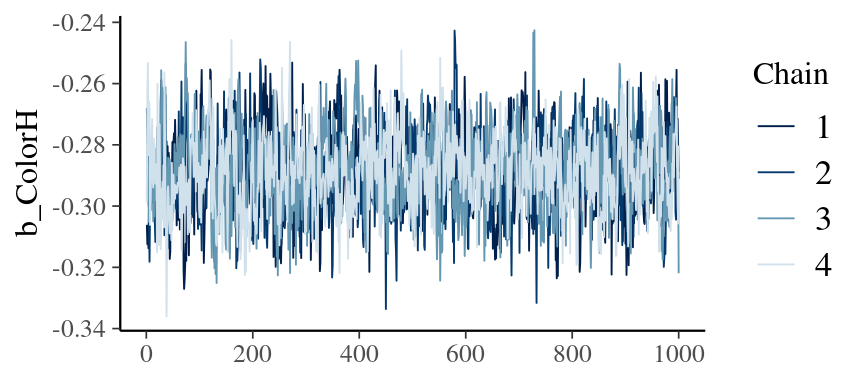

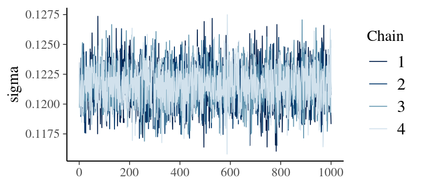

But there are many regression coefficients to plot

## Bayesian multiple regression convergence

Stan

For the Bayesian version with brms we can easily use the same syntax

```r
brmfit_diamonds <- brm(log_Price ~ log_Carats*(Color + Clarity), diamond_data) # run the model
```

Automatic measures of convergence:

```r
#rhat(brmfit_diamonds)
summary(brmfit_diamonds)$fixed$Rhat
```

```
##  [1] 1.003022 1.003828 1.003142 1.002352 1.002345 1.002387 1.001795 1.001775 1.001318 1.001430 1.000269 1.001348
## [13] 1.001118 1.000942 1.000774 1.001532 1.002332 1.001877 1.001096 1.002177 1.002185 1.001173 1.001920 1.001157
## [25] 1.001722 1.002002 1.001007 1.001110
```

\(\hat{R}\), ratio of between chain to in-chain sds

- should be close to 1 (less than 1.05)

```r
#summary(brmfit_diamonds)$fixed$Bulk_ESS
summary(brmfit_diamonds)$fixed$Tail_ESS
```

```
##  [1] 1228.142 1223.394 1768.854 1701.666 1976.699 1825.737 1795.927 1721.958 2309.165 1513.803 1546.288 1322.639
## [13] 1380.833 1348.342 1305.338 2080.159 1834.397 1895.881 2178.357 2280.677 2252.317 3023.679 1572.768 1890.771
## [25] 1376.203 1541.392 1666.827 1620.458
```

Effective Sample Size (ESS), estimate of equivalent number of independent samples

- should be in the 100s

If not, we need to increase the chain lengths (`warmup` and `iter` parameters)

## Regression coefficients

We are interested in the regression coefficients of *Color* and *Clarity*

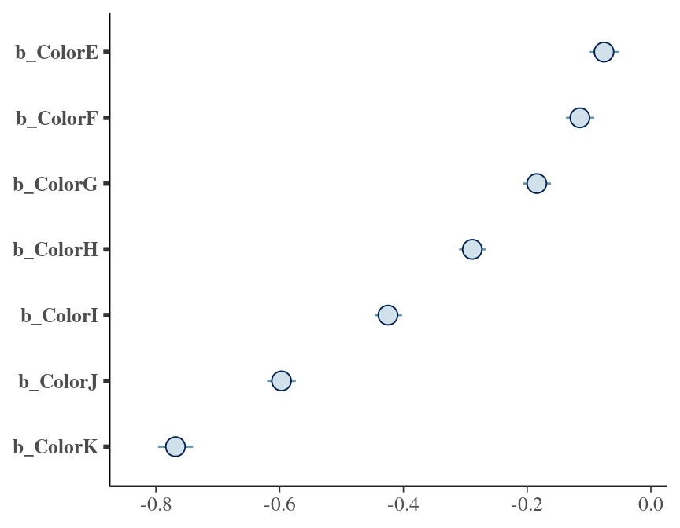

```r
mcmc_plot(brmfit_diamonds, variable = "*_Col*",
          regex = TRUE, type = "intervals")
```

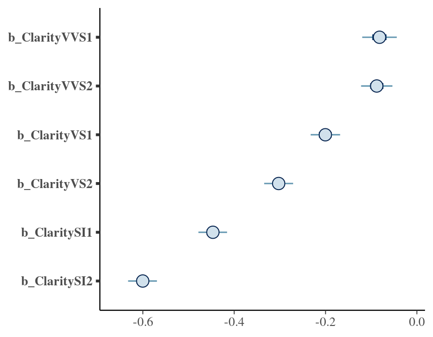

```r
mcmc_plot(brmfit_diamonds, variable = "*_Cla*",
          regex = TRUE, type = "intervals")
```

Both show strong effects

## Interaction effects

And the **interaction** regression coefficients of *Color* and *Clarity* with *log_Carat*

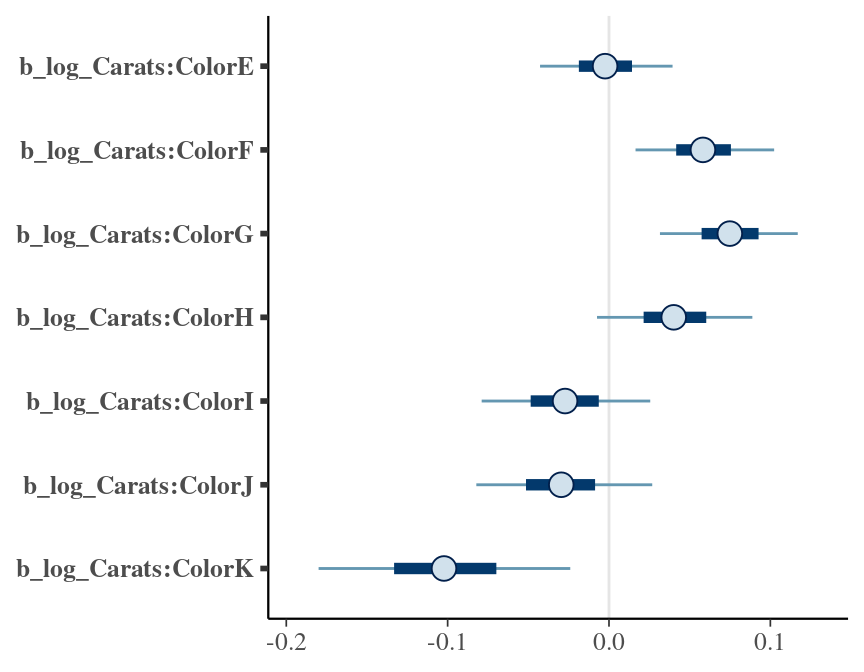

```r
mcmc_plot(brmfit_diamonds, variable = "*:Col*",
          regex = TRUE, type = "intervals")
```

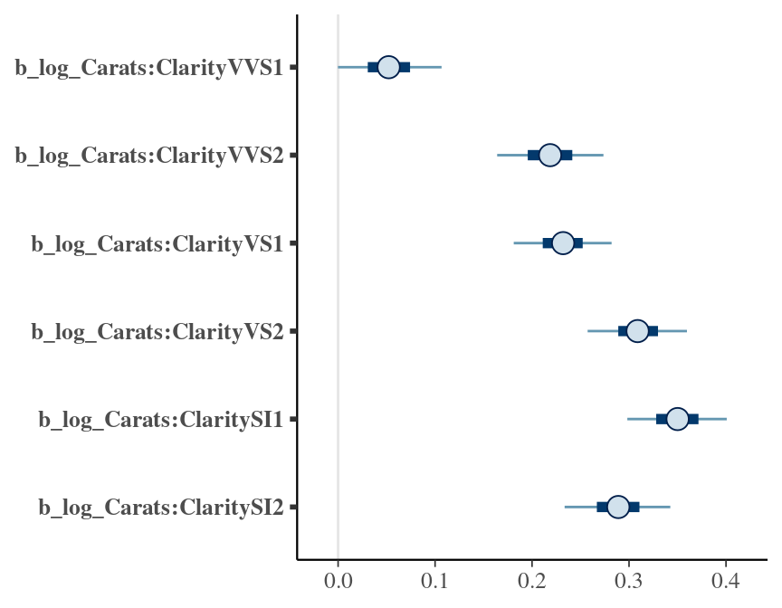

```r
mcmc_plot(brmfit_diamonds, variable = "*:Cla*",
          regex = TRUE, type = "intervals")
```

Weak effect for *Color* and stronger for *Clarity*

## Summary

For multiple linear regression

\[ y = \beta_0 + \beta_1 x_1 + \beta_2 x_2 + \ldots + \epsilon \]

- the predicted value is the linear combination of the terms

Allows adjustment for confounding factors

We may need to transform continuous variables

- for example log transformation, or log-linkage

With brms can again easily run Bayesian multiple regression

- with the same regression formula syntax bf(… ~ …)

We can also easily include interaction between variables

Model checking (and prior definitions!) more involved

\(\rightarrow\) Exercises 7